# Characterization of the Microbiome of a State-of-the-Art Water Reuse System to Enhance Treatment Performance

You will need the initial mapping files for QC, as well as the analysis mapping (Both included in supplementary data on the github repo) file to recreate this analysis.

Software used: - QIIME 1.9.1 - USEARCH v. 10.0.240 - PEAR - All dependencies for the above software

```bash
source activate qiime1
```

Once you’ve downloaded data from the SRA- you need to place it into the R Markdown folder, downloaded from GitHub/Zenodo. Make a directory “seq” within “R Markdown”, and place the raw sequencing files inside as shown below. Sequencing file names may have changed in the SRA from shown in this example.

Base_Dir —> “R Markdown” —> “seq” —> “Run1” —> “Run2” —> “QIIME Files” —> “QIIME Summaries” By the estimated insert sizes for 16S and 18S, we’re going to have to process our Bacterial/Archaeal and Eukaryotic sequences separately- 18S reads will not join (≈600-700 bp, so no overlap). First, we’ll join reads, and then use the unpaired reads into a separate USEARCH pipeline.

```bash
pear -f seq/BS-S1_S1_L001_R1_001.fastq -r seq/July2017/BS-S1_S1_L001_R2_001.fastq -o seq/seqs -p 0.001 -v 50 -m 450 -n 250 -y 500m -j 16

pear -f seq/Parada_Run1_Early2017_R1.fastq -r seq/Parada_Run1_Early2017_R2.fastq -o seq/seqs -p 0.001 -v 50 -m 450 -n 250 -y 500m -j 16
```

After assembly, we’re going to bifurcate into two workflows- the joined (Bacterial/Archaeal) and unjoined (Mostly Eukaryotic) sequences. Unjoined will use the unpaired, raw sequence data. I’ll need to process both the R1 and R2 files to capture all of the sequence reads with a valid barcode and forward primer sequence because of my design.

```bash
extract_barcodes.py -l 12 -a -m map.txt -f seq/July/seqs.assembled.fastq -o seq/July/PreppedJoined/
extract_barcodes.py -l 12 -f seq/July/BS-S1_S1_L001_R1_001.fastq -o seq/July/PreppedF/
extract_barcodes.py -l 12 -f seq/July/BS-S1_S1_L001_R2_001.fastq -o seq/July/PreppedR/

extract_barcodes.py -l 12 -a -m OctoberMap.txt -f seq/October/seqs.assembled.fastq -o seq/October/PreppedJoined/
extract_barcodes.py -l 12 -f seq/Parada_Run1_Early2017_R1.fastq -o seq/October/PreppedF/
extract_barcodes.py -l 12 -f seq/Parada_Run1_Early2017_R2.fastq -o seq/October/PreppedR/
```

Onto demultiplexing. No quality filtering was performed at this point, since the USEARCH pipeline will take the FASTQ file and filter later on.

```bash
split_libraries_fastq.py --barcode_type 12 -i seq/July/PreppedJoined/reads.fastq -b seq/July/PreppedJoined/barcodes.fastq -m JulyMap.txt --phred_quality_threshold 0 --store_demultiplexed_fastq -o seq/July/SlOutJoin/

split_libraries_fastq.py --barcode_type 12 -i seq/July/PreppedF/reads.fastq -b seq/July/PreppedF/barcodes.fastq -m JulyMap.txt --phred_quality_threshold 0 --store_demultiplexed_fastq -o seq/July/SlOut_F/

split_libraries_fastq.py --barcode_type 12 -i seq/July/PreppedR/reads.fastq -b seq/July/PreppedR/barcodes.fastq -m JulyMap.txt --phred_quality_threshold 0 --store_demultiplexed_fastq -o seq/July/SlOut_R/

mkdir seq/July/SlOutUn/
cat seq/July/SlOut_F/seqs.fna seq/July/SlOut_R/seqs.fna > seq/July/SlOutUn/seqs.fna
cat seq/July/SlOut_F/seqs.fastq seq/July/SlOut_R/seqs.fastq > seq/July/SlOutUn/seqs.fastq

split_libraries_fastq.py --barcode_type 12 -i seq/October/PreppedJoined/reads.fastq -b seq/October/PreppedJoined/barcodes.fastq -m OctoberMap.txt --phred_quality_threshold 0 --store_demultiplexed_fastq -o seq/October/SlOutJoin/

split_libraries_fastq.py --barcode_type 12 -i seq/October/PreppedF/reads.fastq -b seq/October/PreppedF/barcodes.fastq -m OctoberMap.txt --phred_quality_threshold 0 --store_demultiplexed_fastq -o seq/October/SlOut_F/

split_libraries_fastq.py --barcode_type 12 -i seq/October/PreppedR/reads.fastq -b seq/October/PreppedR/barcodes.fastq -m OctoberMap.txt --phred_quality_threshold 0 --store_demultiplexed_fastq -o seq/October/SlOut_R/

mkdir seq/October/SlOutUn/
cat seq/October/SlOut_F/seqs.fna seq/October/SlOut_R/seqs.fna > seq/October/SlOutUn/seqs.fna
cat seq/October/SlOut_F/seqs.fastq seq/October/SlOut_R/seqs.fastq > seq/October/SlOutUn/seqs.fastq

mkdir seq/SlOutJoin/
cat seq/July/SlOutJoin/seqs.fna seq/October/SlOutJoin/seqs.fna > seq/SlOutJoin/seqs.fna
cat seq/July/SlOutJoin/seqs.fastq seq/October/SlOutJoin/seqs.fastq > seq/SlOutJoin/seqs.fastq

mkdir seq/SlOutUn/
cat seq/July/SlOutUn/seqs.fna seq/October/SlOutUn/seqs.fna > seq/SlOutUn/seqs.fna
cat seq/July/SlOutUn/seqs.fastq seq/October/SlOutUn/seqs.fastq > seq/SlOutUn/seqs.fastq
```

Now, onto USEARCH

```bash
mkdir UPARSE
mkdir UPARSE/Join/
usearch -fastx_truncate seq/SlOutJoin/seqs.fastq -trunclen 400 -fastqout seq/SlOutJoin/seqs.trunc.fastq
usearch -fastx_truncate seq/SlOutJoin/seqs.fna -trunclen 400 -fastaout seq/SlOutJoin/seqs.trunc.fna
usearch -fastq_filter seq/SlOutJoin/seqs.trunc.fastq -fastaout UPARSE/Join/seqs.filtered.fasta -fastq_maxee 1
usearch -fastx_uniques UPARSE/Join/seqs.filtered.fasta -fastaout UPARSE/Join/uniques.fa -sizeout -relabel Uniq
usearch -unoise3 UPARSE/Join/uniques.fa -zotus UPARSE/Join/zotus.fa
usearch -usearch_global seq/SlOutJoin/seqs.fna -db UPARSE/Join/zotus.fa -strand plus -id 0.99 -uc UPARSE/Join/zotu.map.uc
python /usr/bin/uc2otutab.py UPARSE/Join/zotu.map.uc > UPARSE/Join/zotu-table.txt
biom convert --table-type=\OTU table\ -i UPARSE/Join/zotu-table.txt -o UPARSE/Join/zotu.biom --to-json
assign_taxonomy.py -m mothur -t /media/Storage/DB/silva.nr_v128.tax -r /media/Storage/DB/silva.nr_v128.align -o UPARSE/Join/mothur_taxonomy/ -i UPARSE/Join/zotus.fa
biom add-metadata --sc-separated taxonomy --observation-header OTUID,taxonomy --observation-metadata-fp UPARSE/Join/mothur_taxonomy/zotus_tax_assignments.txt -i UPARSE/Join/zotu.biom -o UPARSE/Join/zotu_w_tax.biom
biom add-metadata -i UPARSE/Join/zotu_w_tax.biom -o UPARSE/Join/zotu_w_md.biom --sample-metadata-fp map.txt


mkdir UPARSE/Un/
usearch -fastq_filter seq/SlOutUn/seqs.fastq -fastaout UPARSE/Un/seqs.filtered.fasta -fastq_maxee 1
usearch -fastx_uniques UPARSE/Un/seqs.filtered.fasta -fastaout UPARSE/Un/uniques.fa -sizeout -relabel Uniq
usearch -unoise3 UPARSE/Un/uniques.fa -zotus UPARSE/Un/zotus.fa
usearch -usearch_global seq/SlOutUn/seqs.fna -db UPARSE/Un/zotus.fa -strand plus -id 0.99 -uc UPARSE/Un/zotu.map.uc
python /usr/bin/uc2otutab.py UPARSE/Un/zotu.map.uc > UPARSE/Un/zotu-table.txt
biom convert --table-type=\OTU table\ -i UPARSE/Un/zotu-table.txt -o UPARSE/Un/zotu.biom --to-json
assign_taxonomy.py -m mothur -t /media/Storage/DB/silva.nr_v128.tax -r /media/Storage/DB/silva.nr_v128.align -o UPARSE/Un/mothur_taxonomy/ -i UPARSE/Un/zotus.fa
biom add-metadata --sc-separated taxonomy --observation-header OTUID,taxonomy --observation-metadata-fp UPARSE/Un/mothur_taxonomy/zotus_tax_assignments.txt -i UPARSE/Un/zotu.biom -o UPARSE/Un/zotu_w_tax.biom
biom add-metadata -i UPARSE/Un/zotu_w_tax.biom -o UPARSE/Un/zotu_w_md.biom --sample-metadata-fp map.txt
```

The next few steps are for filtering of contaminant sequences. I limited the control OTU table to samples with at least 1000 sequences to ensure that I could get a representative “contaminated” core microbiome. All extraction blanks and filtration blanks were identified within the “Sample” metadata category as “Control” within my mapping file.

Operational taxonomic units found to be in 75 percent of my controls will be removed. Also, because I have triplicate samples, I’ll assume any OTU not found in at least 3 samples is erroneous.

```bash
filter_samples_from_otu_table.py -m map.txt -s 'Control:Y' -n 1000 -o UPARSE/Join/Control.biom -i UPARSE/Join/zotu_w_md.biom
compute_core_microbiome.py --min_fraction_for_core 0.25 --max_fraction_for_core 0.75 -i UPARSE/Join/Control.biom -o UPARSE/Join/ControlCore/

filter_otus_from_otu_table.py -e UPARSE/Join/ControlCore/core_otus_75.txt -s 3 -n 1 -i UPARSE/Join/zotu_w_md.biom  -o UPARSE/Join/PostControlFilter.biom
filter_taxa_from_otu_table.py -n Eukaryota -i UPARSE/Join/PostControlFilter.biom -o UPARSE/Join/AnalysisBacArc.biom
filter_samples_from_otu_table.py -n 100 -i UPARSE/Join/AnalysisBacArc.biom -o UPARSE/Join/AnalysisBacArc.clean.biom


filter_samples_from_otu_table.py -m map.txt -s 'Control:Y' -n 1000 -o UPARSE/Un/Control.biom -i UPARSE/Un/zotu_w_md.biom
compute_core_microbiome.py --min_fraction_for_core 0.25 --max_fraction_for_core 0.75 -i UPARSE/Un/Control.biom -o UPARSE/Un/ControlCore/

filter_otus_from_otu_table.py -e UPARSE/Un/ControlCore/core_otus_75.txt -s 3 -n 1 -i UPARSE/Un/zotu_w_md.biom  -o UPARSE/Un/PostControlFilter.biom
filter_taxa_from_otu_table.py -p Eukaryota -i UPARSE/Un/PostControlFilter.biom -o UPARSE/Un/Analysis_Euk.biom
filter_samples_from_otu_table.py -n 100 -i UPARSE/Un/Analysis_Euk.biom -o UPARSE/Un/Analysis_Euk.clean.biom

#Also, one BIOM file for a combined analysis, just to see the Eukarya/Bacteria ratio

filter_samples_from_otu_table.py -n 100 -i UPARSE/Un/PostControlFilter.biom -o UPARSE/Un/Analysis_combined.biom
```

Last step before moving into R. I’m going to extract sOTUs from the initial repset FASTA files to only include those that passed contamination screening. After this, I’ll align to the SILVA database, and then generate phylogenetic trees, useful for the Unifrac distance matrix.

```bash
filter_fasta.py -b UPARSE/Join/AnalysisBacArc.clean.biom -f UPARSE/Join/zotus.fa -o UPARSE/Join/BacArc.seqs.fna
filter_fasta.py -b UPARSE/Un/Analysis_Euk.clean.biom -f UPARSE/Un/zotus.fa -o UPARSE/Un/Euk.seqs.fna

#Combined
filter_fasta.py -b UPARSE/Un/Analysis_combined.biom -f UPARSE/Un/zotus.fa -o UPARSE/Un/All.seqs.fna
```

Back to the M4.4xlarge instance type for sequence alignment.

```bash
align_seqs.py -i UPARSE/Join/BacArc.seqs.fna -t /media/Storage/DB/SILVA_128_QIIME_release/rep_set_aligned/97/97_otus_aligned.fasta -o UPARSE/Join/Aligned/
filter_alignment.py -i UPARSE/Join/Aligned/BacArc.seqs_aligned.fasta -o UPARSE/Join/Aligned/ -e 0.001
make_phylogeny.py -i UPARSE/Join/Aligned/BacArc.seqs_aligned_pfiltered.fasta -o UPARSE/Join/BacArc.tre

align_seqs.py -i UPARSE/Un/Euk.seqs.fna -t /media/Storage/DB/SILVA_128_QIIME_release/rep_set_aligned/97/97_otus_aligned.fasta -o UPARSE/Un/Aligned/
filter_alignment.py -i UPARSE/Un/Aligned/Euk.seqs_aligned.fasta -o UPARSE/Un/Aligned/ -e 0.001
make_phylogeny.py -i UPARSE/Un/Aligned/Euk.seqs_aligned_pfiltered.fasta -o UPARSE/Un/Euk.tre

#Combined
align_seqs.py -i UPARSE/Un/All.seqs.fna -t /media/Storage/DB/SILVA_128_QIIME_release/rep_set_aligned/97/97_otus_aligned.fasta -o UPARSE/Un/AllAligned/
filter_alignment.py -i UPARSE/Un/AllAligned/All.seqs_aligned.fasta -o UPARSE/Un/AllAligned/ -e 0.001
make_phylogeny.py -i UPARSE/Un/AllAligned/All.seqs_aligned_pfiltered.fasta -o UPARSE/Un/All.tre
```

Onto R. This can be run on (almost) any desktop/laptop without issue. In my case, I downloaded the above output files (.biom, .tre. and .fa) from my workstation onto my laptop to run the below.

Load Needed Libraries

```r
library(phyloseq)
library(ampvis)
library(cowplot)
```

Import BIOM files and convert to a phyloseq object. Also, I’ll need to rename the columns to match what Phyloseq/Ampvis expect and make my life a little simpler. This will be a large section as I import each file. The “Analysis combined” phyloseq object wasn’t used in the manuscript, but might be of interest if you want to see the bacteria, archaea, and eukaryotes in a single figure.

```r
Overall.BA <- import_biom("AnalysisBacArc.clean.fix.biom", "BacArc.tre", "BacArc.seqs.fna", parseFunction=parse_taxonomy_default)
Overall.E <- import_biom("AnalysisEuk.clean.fix.biom", "Euk.tre", "Euk.seqs.fna", parseFunction=parse_taxonomy_default)
Overall.All <- import_biom("Analysis_combined.fix.biom", "All.tre", "All.seqs.fna", parseFunction=parse_taxonomy_default)
```

```r
colnames(tax_table(Overall.BA)) = c("Kingdom", "Phylum", "Class", "Order", "Family", "Genus", "Species")
colnames(tax_table(Overall.E)) = c("Kingdom", "Phylum", "Class", "Order", "Family", "Genus", "Species")
colnames(tax_table(Overall.All)) = c("Kingdom", "Phylum", "Class", "Order", "Family", "Genus", "Species")
```

Now I’m going to subset each table to make individual heatmaps for water and biofilm samples that I can place side by side in the manuscript.

```r
Overall.BA.N <- transform_sample_counts(Overall.BA, function(x) x / sum(x) * 100)
Overall.E.N <- transform_sample_counts(Overall.E, function(x) x / sum(x) * 100)
Experimental.BA <- subset_samples(Overall.BA, Site %in% c("Q1", "MFF", "MFE" , "ROF", "ROP", "UVF", "UVP", "FPW", "RO", "MF"))
Experimental.E <- subset_samples(Overall.E, Site %in% c("Q1", "MFF", "MFE" , "ROF", "ROP", "UVF", "UVP", "FPW", "RO", "MF"))
Experimental.BA.N <- transform_sample_counts(Experimental.BA, function(x) x / sum(x) * 100)
Experimental.E.N <- transform_sample_counts(Experimental.E, function(x) x / sum(x) * 100)
Water.BA <- subset_samples(Experimental.BA, Site %in% c("Q1", "MFF", "MFE" , "ROF", "ROP", "UVF", "UVP", "FPW"))
Water.BA <- subset_samples(Water.BA, SampleType %in% c("Water"))
Water.E <- subset_samples(Experimental.E, Site %in% c("Q1", "MFF", "MFE" , "ROF", "ROP", "UVF", "UVP", "FPW"))
Water.E <- subset_samples(Water.E, SampleType %in% c("Water"))
Water.BA.N <- transform_sample_counts(Water.BA, function(x) x / sum(x) * 100)
Water.E.N <- transform_sample_counts(Water.E, function(x) x / sum(x) * 100)
Water.DNA.BA <- subset_samples(Water.BA, DNAorRNA %in% c("DNA"))
Water.DNA.E <- subset_samples(Water.E, DNAorRNA %in% c("DNA"))
Water.BA.DNA.N <- transform_sample_counts(Water.DNA.BA, function(x) x / sum(x) * 100)
Water.E.DNA.N <- transform_sample_counts(Water.DNA.E, function(x) x / sum(x) * 100)
Biofilm.BA <- subset_samples(Overall.BA, Site %in% c("RO", "MF"))
Biofilm.BA.N <- transform_sample_counts(Biofilm.BA, function(x) x / sum(x) * 100)
Biofilm.E <- subset_samples(Overall.E, Site %in% c("RO", "MF"))
Biofilm.E.N <- transform_sample_counts(Biofilm.E, function(x) x / sum(x) * 100)
```

Now, let’s address our first question- are the sample sites/control points different?

For the next section, we want to confirm that there are visible differences between sample sites by ordination, and then test the hypothesis that there is a difference in community structure between sample sites. To do this, we’re going to rarefy our phyloseq objects before proceeding.

```r
Water.BA.Rare <- rarefy_even_depth(Water.BA, sample.size = 5000, rngseed = 712)
```

```
`set.seed(712)` was used to initialize repeatable random subsampling.
Please record this for your records so others can reproduce.
Try `set.seed(712); .Random.seed` for the full vector
...
9 samples removedbecause they contained fewer reads than `sample.size`.
Up to first five removed samples are:

ROP.2.RNAQ1.4.DNAQ1.3.RNAUVP.4.DNAQ1.1.DNA
...
1072OTUs were removed because they are no longer
present in any sample after random subsampling

...
```

```r
Water.E.Rare <- rarefy_even_depth(Water.E, sample.size = 1000, rngseed = 712)
```

```
`set.seed(712)` was used to initialize repeatable random subsampling.
Please record this for your records so others can reproduce.
Try `set.seed(712); .Random.seed` for the full vector
...
15 samples removedbecause they contained fewer reads than `sample.size`.
Up to first five removed samples are:

UVP.1.DNAUVP.1.RNAQ1.1.DNAQ1.4.DNAMFE.4.DNA
...
93OTUs were removed because they are no longer
present in any sample after random subsampling

...
```

```r
Experimental.BA.Rare <- rarefy_even_depth(Experimental.BA, sample.size = 5000, rngseed = 712)
```

```
`set.seed(712)` was used to initialize repeatable random subsampling.
Please record this for your records so others can reproduce.
Try `set.seed(712); .Random.seed` for the full vector
...
12 samples removedbecause they contained fewer reads than `sample.size`.
Up to first five removed samples are:

MF.Biofilm.3.RNAROP.2.RNAQ1.4.DNAMF.Biofilm.4.DNAQ1.3.RNA
...
742OTUs were removed because they are no longer
present in any sample after random subsampling

...
```

```r
Experimental.E.Rare <- rarefy_even_depth(Experimental.E, sample.size = 1000, rngseed = 712)
```

```
`set.seed(712)` was used to initialize repeatable random subsampling.
Please record this for your records so others can reproduce.
Try `set.seed(712); .Random.seed` for the full vector
...
27 samples removedbecause they contained fewer reads than `sample.size`.
Up to first five removed samples are:

UVP.1.DNARO.Biofilm.Sept2017.3.DNAUVP.1.RNARO.Biofilm.Alt.3.RNAMF.Biofilm.1.RNA
...
51OTUs were removed because they are no longer
present in any sample after random subsampling

...
```

```r
Water.DNA.BA.Rare <- rarefy_even_depth(Water.DNA.BA, sample.size = 1000, rngseed = 712)
```

```
`set.seed(712)` was used to initialize repeatable random subsampling.
Please record this for your records so others can reproduce.
Try `set.seed(712); .Random.seed` for the full vector
...
2573OTUs were removed because they are no longer
present in any sample after random subsampling

...
```

```r
Water.DNA.E.Rare <- rarefy_even_depth(Water.DNA.E, sample.size = 1000, rngseed = 712)
```

```
`set.seed(712)` was used to initialize repeatable random subsampling.
Please record this for your records so others can reproduce.
Try `set.seed(712); .Random.seed` for the full vector
...
9 samples removedbecause they contained fewer reads than `sample.size`.
Up to first five removed samples are:

UVP.1.DNAQ1.1.DNAQ1.4.DNAMFE.4.DNAMFE.1.DNA
...
219OTUs were removed because they are no longer
present in any sample after random subsampling

...
```

Next, I’m going to define a color varible for the plots. The colors were chosen to be colorblind friendly using http://colorbrewer2.org/.

```r
cols <- c("Q1" = "#762a83", "MFF" = "#9970ab", "MFE" = "#c2a5cf", "ROF" = "#e7d4e8", "ROP" = "#d9f0d3", "UVF" = "#a6dba0", "UVP" = "#5aae61", "FPW" = "#1b7837", "RO" = "#40004b", "MF" = "#00441b")
```

First off, let’s generate some PCoA ordinations that will be figures in the manuscript.

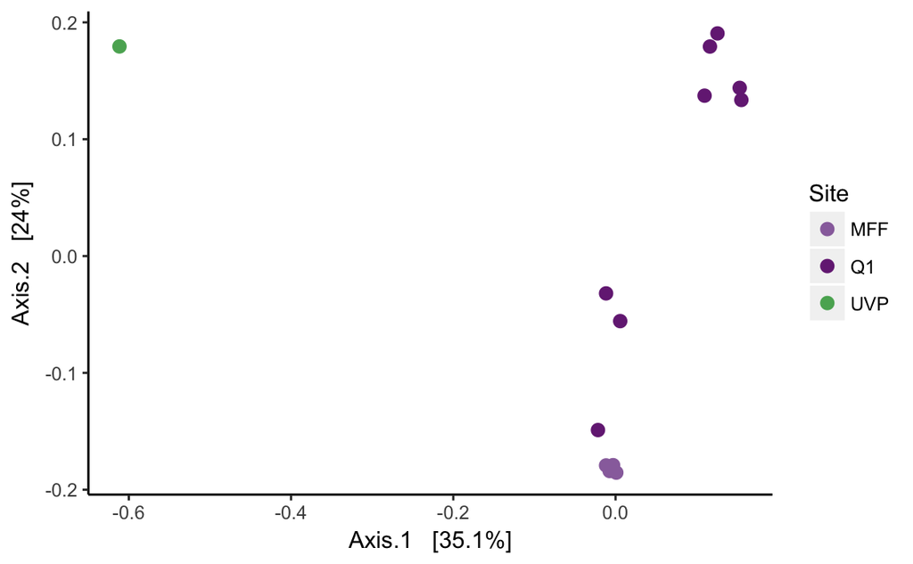

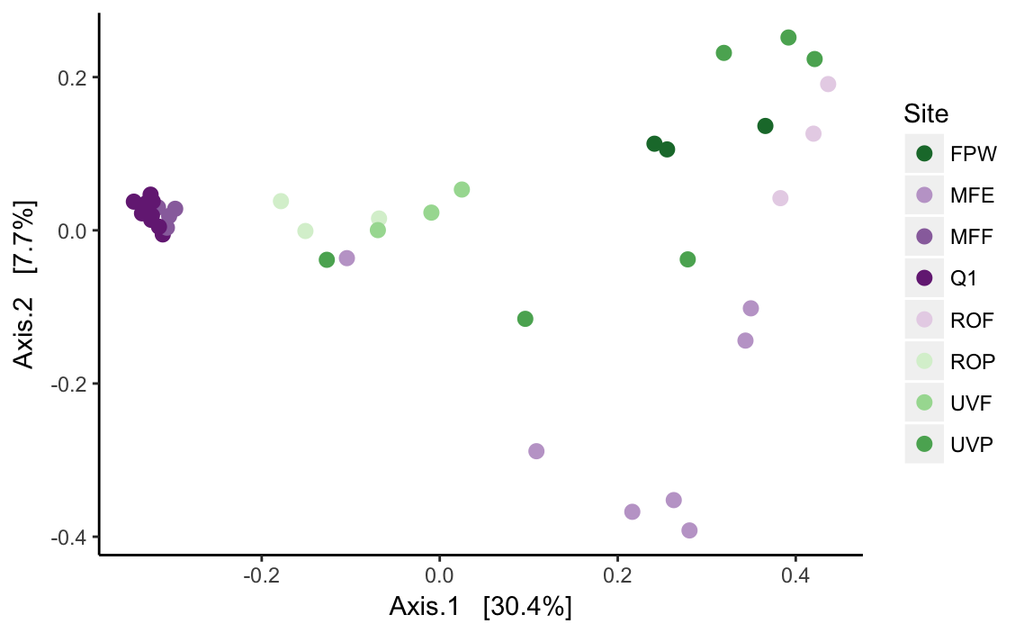

There appears to be a general trend of samples clustering before RO treatment, though also more strongly before microfiltration (MF). If we look at the actual taxa found, we might see a more clear trend.

Next, we can generate heatmaps as shown in the manuscript.

```
Transformation introduced infinite values in discrete y-axisTransformation introduced infinite values in discrete y-axis
```

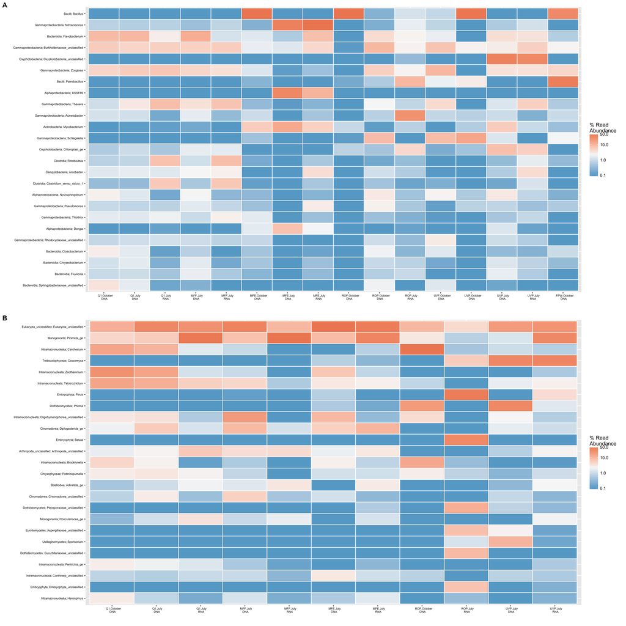

```r
plot_grid(BA.Water.Heat,E.Water.Heat, labels = c("A", "B"), rel_widths = c(1,1),nrow = 2, align = "v")
```

```
Transformation introduced infinite values in discrete y-axisTransformation introduced infinite values in discrete y-axis
```

[figure not shown]

```r
BA.Biofilm.Heat<- amp_heatmap(data = Biofilm.BA.N,
            tax.aggregate = "Genus",
            tax.add = "Class",
            group = c("SiteType"),
            tax.show = 25,
            tax.empty = "remove",
            plot.numbers = F,
            plot.breaks = c(0.1,1.0,10.0,50.0),
            max.abundance = 50,
            min.abundance = .1,
            order.x = c("MF.RNA","MF.DNA","RO.DNA","RO.RNA"),
            scale.seq = 100) +
    scale_x_discrete(labels = c("MF\nRNA","MF\nDNA","RO\nDNA","RO\nRNA")) +
    theme(axis.text.x = element_text(size =6, color = "black", hjust = 0.4, angle = 0)) + theme(axis.text.y = element_text(size =6, color = "black", angle = 0))
BA.Biofilm.Heat<- amp_heatmap(data = Biofilm.BA.N,
            tax.aggregate = "Genus",
            tax.add = "Class",
            group = c("SiteType"),
            tax.show = 25,
            tax.empty = "remove",
            plot.numbers = F,
            plot.breaks = c(0.1,1.0,10.0,50.0),
            max.abundance = 50,
            min.abundance = .1,
            order.x = c("MF.RNA","MF.DNA","RO.DNA","RO.RNA"),
            scale.seq = 100) +
    scale_x_discrete(labels = c("MF\nRNA","MF\nDNA","RO\nDNA","RO\nRNA")) +
    theme(axis.text.x = element_text(size =6, color = "black", hjust = 0.4, angle = 0)) + theme(axis.text.y = element_text(size =6, color = "black", angle = 0))
E.Biofilm.Heat<- amp_heatmap(data = Biofilm.E.N,
            tax.aggregate = "Genus",
            tax.add = "Class",
            group = c("SiteType"),
            tax.show = 25,
            tax.empty = "remove",
            plot.numbers = F,
            plot.breaks = c(0.1,1.0,10.0,50.0),
            max.abundance = 50,
            min.abundance = .1,
            order.x = c("MF.RNA","MF.DNA","RO.DNA","RO.RNA"),
            scale.seq = 100) +
    scale_x_discrete(labels = c("MF\nRNA","MF\nDNA","RO\nDNA","RO\nRNA")) +
    theme(axis.text.x = element_text(size =6, color = "black", hjust = 0.4, angle = 0)) + theme(axis.text.y = element_text(size =6, color = "black", angle = 0))
E.Biofilm.Heat<- amp_heatmap(data = Biofilm.E.N,
            tax.aggregate = "Genus",
            tax.add = "Class",
            group = c("SiteType"),
            tax.show = 25,
            tax.empty = "remove",
            plot.numbers = F,
            plot.breaks = c(0.1,1.0,10.0,50.0),
            max.abundance = 50,
            min.abundance = .1,
            order.x = c("MF.RNA","MF.DNA","RO.DNA","RO.RNA"),
            scale.seq = 100) +
    scale_x_discrete(labels = c("MF\nRNA","MF\nDNA","RO\nDNA","RO\nRNA")) +
    theme(axis.text.x = element_text(size =6, color = "black", hjust = 0.4, angle = 0)) + theme(axis.text.y = element_text(size =6, color = "black", angle = 0))
plot_grid(BA.Biofilm.Heat,E.Biofilm.Heat, labels = c("A", "B"), rel_widths = c(1,1),nrow = 2, align = "v")
```

There are definitely differences in both the bacteria and eukaryotes, though the effect is more pronounced in the bacteria. The heatmaps were exported as PDFs, and combined using Graphic to make the final figure. Now, to run statistical tests to confirm this observation.

```r
Experimental.BA.Rare.Data = as(sample_data(Experimental.BA.Rare), "data.frame")
Experimental.BA.d = phyloseq::distance(Experimental.BA.Rare, "wunifrac")
```

```
Randomly assigning root as -- Zotu3842 -- in the phylogenetic tree in the data you provided.
```

```r
adonis(Experimental.BA.d ~ Site, permutations = 999, Experimental.BA.Rare.Data)
```

```
Call:
adonis(formula = Experimental.BA.d ~ Site, data = Experimental.BA.Rare.Data,      permutations = 999)

Permutation: free
Number of permutations: 999

Terms added sequentially (first to last)

          Df SumsOfSqs  MeanSqs F.Model      R2 Pr(>F)
Site       9    2.3205 0.257832  6.8052 0.49295  0.001 ***
Residuals 63    2.3869 0.037887         0.50705
Total     72    4.7074                  1.00000
---
Signif. codes:  0 ‘***’ 0.001 ‘**’ 0.01 ‘*’ 0.05 ‘.’ 0.1 ‘ ’ 1
```

With all samples (including the biofilms), there is a significant difference between sample sites. What about just the water?

```r
Water.BA.Rare.Data = as(sample_data(Water.BA.Rare), "data.frame")
Water.BA.d = phyloseq::distance(Water.BA.Rare, "wunifrac")
```

```
Randomly assigning root as -- Zotu2952 -- in the phylogenetic tree in the data you provided.
```

```r
adonis(Water.BA.d ~ Site, permutations = 999, Water.BA.Rare.Data)
```

```
Call:
adonis(formula = Water.BA.d ~ Site, data = Water.BA.Rare.Data,      permutations = 999)

Permutation: free
Number of permutations: 999

Terms added sequentially (first to last)

          Df SumsOfSqs MeanSqs F.Model      R2 Pr(>F)
Site       7    2.3074 0.32962  7.3683 0.55118  0.001 ***
Residuals 42    1.8789 0.04473         0.44882
Total     49    4.1862                 1.00000
---
Signif. codes:  0 ‘***’ 0.001 ‘**’ 0.01 ‘*’ 0.05 ‘.’ 0.1 ‘ ’ 1
```

```r
Water.E.Rare.Data = as(sample_data(Water.E.Rare), "data.frame")
Water.E.d = phyloseq::distance(Water.E.Rare, "wunifrac")
```

```
Randomly assigning root as -- Zotu10278 -- in the phylogenetic tree in the data you provided.
```

```r
adonis(Water.E.d ~ Site, permutations = 999, Water.E.Rare.Data)
```

```
Call:
adonis(formula = Water.E.d ~ Site, data = Water.E.Rare.Data,      permutations = 999)

Permutation: free
Number of permutations: 999

Terms added sequentially (first to last)

          Df SumsOfSqs  MeanSqs F.Model     R2 Pr(>F)
Site       3    0.7391 0.246367   4.152 0.3615  0.003 **
Residuals 22    1.3054 0.059337         0.6385
Total     25    2.0445                  1.0000
---
Signif. codes:  0 ‘***’ 0.001 ‘**’ 0.01 ‘*’ 0.05 ‘.’ 0.1 ‘ ’ 1
```

Again, highly significant with a strong effect size for the bacteria/archaea and a moderate effect size for the eukaryotes.

# Supplemental Data

First up- I want to show my controls.

```
Transformation introduced infinite values in discrete y-axisTransformation introduced infinite values in discrete y-axis
```

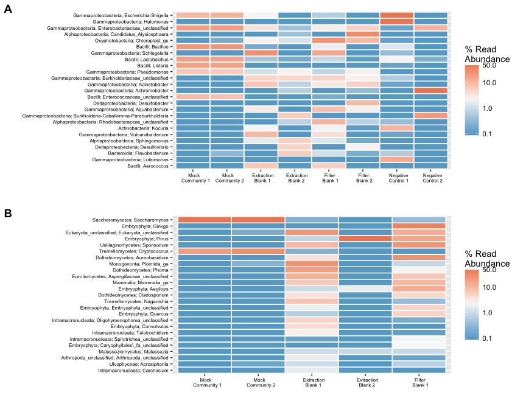

What we see above is that a) the mock community used was near identical between two sequencing runs, and b) negative controls were dissimilar between runs, and contained some known “contaminome” type sequences, such as Halomonas, Achromobacter, etc. Thankfully, the most/more abundant taxa in my actual samples do not match the distribution of my controls.

Next, I’d like to show my no RT controls next to their respective RNA samples.

```
Transformation introduced infinite values in discrete y-axisTransformation introduced infinite values in discrete y-axis
```

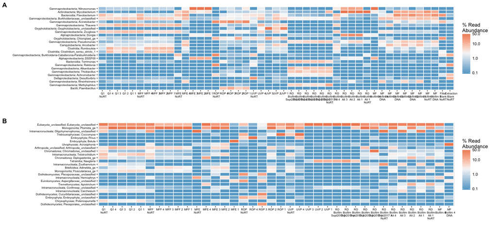

So, our no RT controls look quite a bit more like the DNA samples in figure 4a/b than the RNA samples they are compared to. Always a good thing.